# Albatross Bigelow Conversion Check

Adam A. Kemberling / Andrew Allyn

2021-02-18

# About

This report seeks to check the accuracy of the spring and fall conversions of haddock biomass from the nefsc groundfish survey data.

## Load the Data

We have two datasets:

- A full survdat pull of the groundfish data including data from both survey vessels, with abundance and biomass adjusted in bigelow survey years
- A Bigelow only survey data set that has not been adjusted to reflect expected catch under the albatross survey

```r
# 2020 data
load(paste0(res_path, "NMFS_trawl/Survdat_Nye_Aug 2020.RData"))
survdat_2020 <- survdat %>% clean_names() %>%
    filter(est_year >= 2008)
rm(survdat)

# 2021 data
load(paste0(res_path,   "NMFS_trawl/survdat_slucey_01152021.RData"))
survdat_2021 <- survdat %>% clean_names() %>%
    filter(year >= 2008)
rm(survdat)

# 2021 Bigelow only, un-adjusted
load(paste0(res_path,   "NMFS_trawl/survdat_Bigelow_slucey_01152021.RData"))
survdat_bigelow <- survdat.big %>% clean_names()%>%
    filter(year >= 2008)
rm(survdat.big)



####  02-18-2021
load(paste0(res_path,   "NMFS_trawl/Survdat_02182021.RData"))
feb_2021 <- survdat %>% clean_names()%>%
    filter(year >= 2008)
rm(survdat)

# # Same one but with better documentation
# load(paste0(res_path,   "NMFS_trawl/NEFSC_BTS_02182021.RData"))
# feb_2021_2 <- survey$survdat %>%
#   clean_names() %>%
#   filter(year >= 2008)
# rm(survey)
```

### Data Cleanup

Goal is to zero in on the application of the catch conversion used to account for the change in survey vessel and gear that occurred in 2008 when the survey vessel changed from the RV Albatross to the RV Bigelow.

The conversion factors for haddock catch are: `spring = abundance * .972` and `fall = abundance * 1.816`

```r
# Cleanup functions
source(here("R/01_nefsc_ss_build.R"))

# Put in list to apply all steps to  each
survdat_sources <- list("2020" = survdat_2020,
                        "2021" = survdat_2021,
                        "2021 Bigelow" = survdat_bigelow,
                        "2021 DBI Fix" = feb_2021)


# Run them through cleanup and add length weight info
sources_clean <- survdat_sources %>% map(function(survdat){
  survdat %>%
    survdat_prep() %>%
    add_lw_info() %>%
    filter(comname == "haddock")})
```

### Annual Biomass

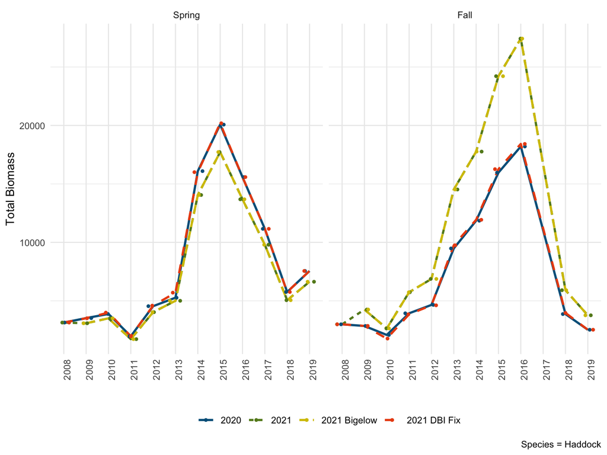

```r
annual_summary <- sources_clean %>%
  imap_dfr(function(survdat, survdat_label){
    survdat %>%
      distinct(id, est_year, season, comname, abundance, biom_adj) %>%
      group_by(est_year, season) %>%
      summarise(total_biomass = sum(biom_adj),
                total_abundance = sum(abundance)) %>%
      ungroup() %>%
      mutate(season = str_to_title(season),
             season = fct_rev(season),
             year = factor(est_year))},
    .id = "survdat_pull")


# Biomass Plot
annual_summary %>%
  ggplot(aes(year, total_biomass, color = survdat_pull)) +
    geom_line(aes(linetype = survdat_pull, group = survdat_pull), size = 1) +
    geom_jitter(width = 0.25, size = 1) +
    scale_color_gmri() +
    facet_wrap(~season) +
    theme(legend.position = "bottom", legend.title = element_blank(),
          axis.text.x = element_text(angle = 90)) +
    labs(x = "",
         y = "Total Biomass",
         caption = "Species = Haddock")
```

### Annual Abundances

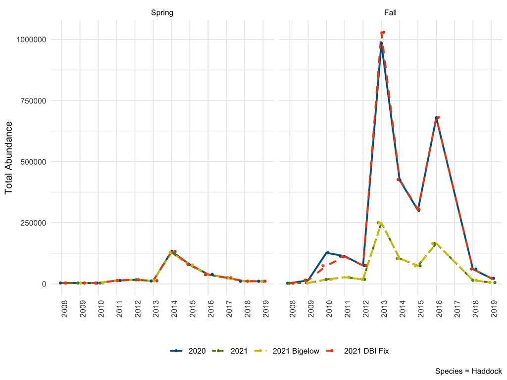

```r
# Biomass Plot
annual_summary %>%
  ggplot(aes(year, total_abundance, color = survdat_pull)) +
    geom_line(aes(linetype = survdat_pull, group = survdat_pull), size = 1) +
    geom_jitter(width = 0.25, size = 1) +
    scale_color_gmri() +
    facet_wrap(~season) +
    theme(legend.position = "bottom", legend.title = element_blank(),
          axis.text.x = element_text(angle = 90)) +
    labs(x = "",
         y = "Total Abundance",
         caption = "Species = Haddock")
```

### Is 2021 just not adjusted

Maybe the 2021 pull is just missing the survey vessel conversions. To test this I’m just going to apply those conversion factors to the survdat.bigelow data and see where it plots.

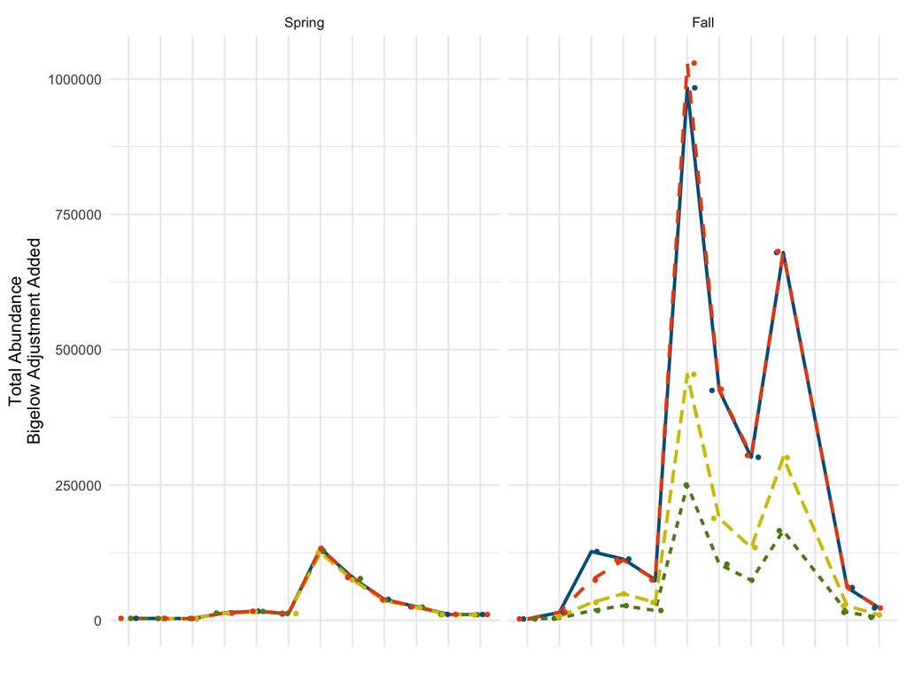

```r
survdat_readjust <- annual_summary %>%
  mutate(
    adjusted_abundance = case_when(
      survdat_pull == "2021 Bigelow" & season == "Spring" ~ total_abundance * 0.972,
      survdat_pull == "2021 Bigelow" & season == "Fall" ~ total_abundance * 1.816,
      TRUE ~ total_abundance))


# Abundance
abund <- survdat_readjust %>%
  ggplot(aes(year, adjusted_abundance, color = survdat_pull)) +
    geom_line(aes(linetype = survdat_pull, group = survdat_pull), size = 1) +
    geom_jitter(width = 0.25, size = 1) +
    scale_color_gmri() +
    facet_wrap(~season) +
    theme(legend.position = "none",
          axis.text.x = element_blank()) +
    labs(x = "", y = "Total Abundance\nBigelow Adjustment Added")


abund
```

A work by [Adam A. Kemberling](https://github.com/adamkemberling/)

*Akemberling@gmri.org*